# Homework 1

John Chen

27 January 2024

# Goals

- We are trying to answer the question: When and where do most break and entries occur in Toronto?.

# Data Set and Cleaning

- We are using [break and enter open data set](https://data.torontopolice.on.ca/datasets/040ead448df2412da252cfbb532e77ac_0/explore?location=43.730563%2C-79.293781%2C10.56) in Toronto from the Toronto Police Service.

```r
str(toronto_be)
```

```
## 'data.frame':    70148 obs. of  31 variables:
##  $ X                : num  -8825841 -8832276 -8840192 -8833225 -8828638 ...
##  $ Y                : num  5417937 5413747 5411580 5410867 5420474 ...
##  $ OBJECTID         : int  1 2 3 4 5 6 7 8 9 10 ...
##  $ EVENT_UNIQUE_ID  : chr  "GO-20141259602" "GO-20141260079" "GO-20141260521" "GO-20141260701" ...
##  $ REPORT_DATE      : chr  "2014/01/01 05:00:00+00" "2014/01/01 05:00:00+00" "2014/01/01 05:00:00+00" "2014/01/01 05:00:00+00" ...
##  $ OCC_DATE         : chr  "2013/12/31 05:00:00+00" "2013/12/31 05:00:00+00" "2014/01/01 05:00:00+00" "2014/01/01 05:00:00+00" ...
##  $ REPORT_YEAR      : int  2014 2014 2014 2014 2014 2014 2014 2014 2014 2014 ...
##  $ REPORT_MONTH     : chr  "January" "January" "January" "January" ...
##  $ REPORT_DAY       : int  1 1 1 1 1 1 1 1 1 1 ...
##  $ REPORT_DOY       : int  1 1 1 1 1 1 1 1 1 1 ...
##  $ REPORT_DOW       : chr  "Wednesday " "Wednesday " "Wednesday " "Wednesday " ...
##  $ REPORT_HOUR      : int  0 1 2 3 10 3 2 1 14 23 ...
##  $ OCC_YEAR         : int  2013 2013 2014 2014 2014 2014 2014 2014 2014 2014 ...
##  $ OCC_MONTH        : chr  "December" "December" "January" "January" ...
```

[output cut: 17 more lines]

```r
sum(is.na.data.frame(toronto_be))
```

```
## [1] 6
```

```r
unique(toronto_be$OFFENCE)
```

```
## [1] "B&E W'Intent"                 "B&E"
## [3] "Unlawfully In Dwelling-House" "B&E Out"
## [5] "B&E - To Steal Firearm"       "B&E - M/Veh To Steal Firearm"
```

- There are 6 missing values which were converted to NA by read.csv. This dataset has 70148 observations and 31 variables. Based on our data, the key variables relates to occurence time and the locations of the break and enter. So variables that starts with OCC, which records the time of break in, neighbourhood, longitude & latitude. All the offence all qualifies as break and enter.

```r
toronto_be <- toronto_be[c("OCC_YEAR","OCC_MONTH","OCC_DAY","OCC_HOUR","NEIGHBOURHOOD_158", "LONG_WGS84","LAT_WGS84","PREMISES_TYPE")]
toronto_be <- toronto_be %>%
  rename(
    day = OCC_DAY,
    hour = OCC_HOUR,
    year = OCC_YEAR,
    month = OCC_MONTH,
    lon = LONG_WGS84,
    lat = LAT_WGS84,
    hood = NEIGHBOURHOOD_158,
    type = PREMISES_TYPE
  )
toronto_be$month <- match(toronto_be$month, month.name)
toronto_be$hood <- factor(toronto_be$hood)
summary(toronto_be)
```

```
##       year          month             day             hour
##  Min.   :2001   Min.   : 1.000   Min.   : 1.00   Min.   : 0.00
##  1st Qu.:2016   1st Qu.: 4.000   1st Qu.: 8.00   1st Qu.: 4.00
##  Median :2018   Median : 7.000   Median :16.00   Median :10.00
##  Mean   :2018   Mean   : 6.653   Mean   :15.66   Mean   :10.56
##  3rd Qu.:2021   3rd Qu.:10.000   3rd Qu.:23.00   3rd Qu.:17.00
##  Max.   :2023   Max.   :12.000   Max.   :31.00   Max.   :23.00
##  NA's   :2      NA's   :2        NA's   :2
##                       hood            lon              lat
##  Annex                  : 1526   Min.   :-79.64   Min.   : 0.00
##  Moss Park              : 1510   1st Qu.:-79.45   1st Qu.:43.66
##  Kensington-Chinatown   : 1426   Median :-79.39   Median :43.69
##  West Humber-Clairville : 1384   Mean   :-78.82   Mean   :43.39
##  Wellington Place       : 1327   3rd Qu.:-79.33   3rd Qu.:43.75
##  York University Heights: 1249   Max.   :  0.00   Max.   :43.84
##  (Other)                :61726
##      type
##  Length:70148
##  Class :character
##  Mode  :character
##
##
##
##
```

There are longitude and latitude values that are outside of the Toronto range. Those should be removed. The range of Toronto is roughly defined between -79.1 to -79.7 and 43.6 to 43.9, longitude and latitude, respectively. Also removed any observation that has 0 value for hour.

```r
toronto_be <- subset(toronto_be, lon < -79.1 & lon > -79.7 & lat < 43.9 & lat > 43.6)
toronto_be <- subset(toronto_be, hour != 0)
```

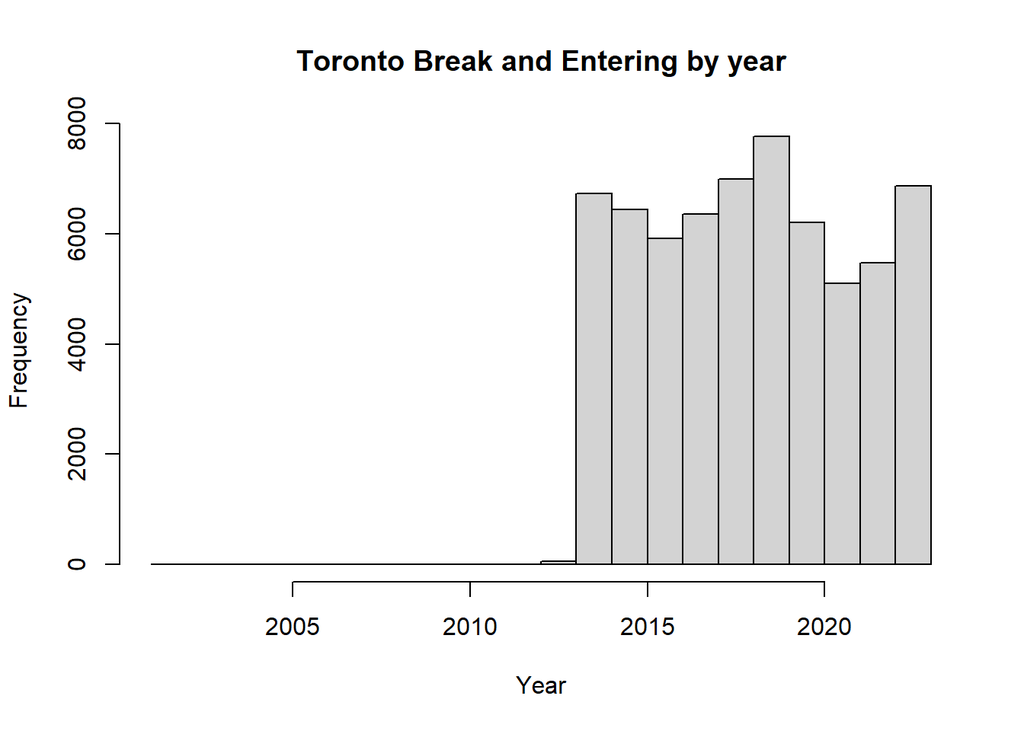

```r
hist(toronto_be$year,
     main = "Toronto Break and Entering by year",
     xlab = "Year")
```

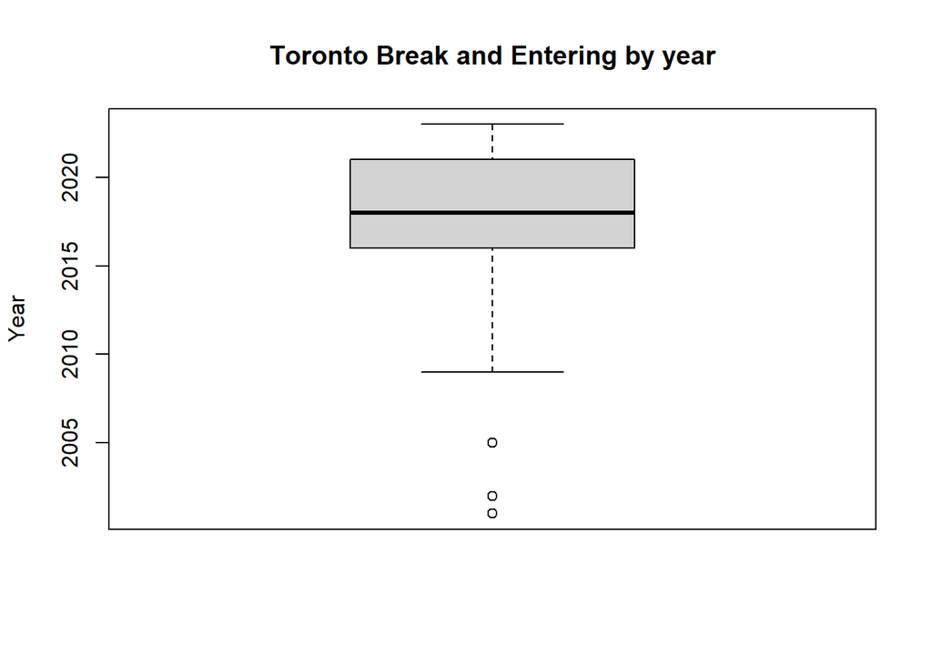

```r
boxplot(toronto_be$year,
     main = "Toronto Break and Entering by year",
     ylab = "Year")
```

```r
toronto_be <- subset(toronto_be, year >= 2014)
```

- There is an sudden increase of occurrence of break and entering in 2014. It could be due to the sudden increased awareness for terrorism. If that’s the case, data before 2014 might not be representative of actual occurrences. Also due to the nature of our investigation, we should only focus on the clump of data. Data before 2014 is removed. Based on the boxplot, there were 3 outliers in the past. Those were removed in the process.

Creating a variable for season and investigate relationships

If I were to choose a time to break and enter, it would be in the darker hours. Since the sun goes down at different time for each season. There could be a relationship between hour and season.

```r
toronto_be <- toronto_be %>% mutate(
  season = case_when(
    month >= 3 & month < 6 ~ "spring",
    month >= 6 & month < 9 ~ "summer",
    month >= 9 & month < 12 ~ "autumn",
    month >= 12 | month < 3 ~ "winter"
  )
)
tapply(toronto_be$hour, toronto_be$season, summary)
```

```
## $autumn
##    Min. 1st Qu.  Median    Mean 3rd Qu.    Max.
##    1.00    5.00   12.00   11.51   17.00   23.00
##
## $spring
##    Min. 1st Qu.  Median    Mean 3rd Qu.    Max.
##    1.00    5.00   11.00   11.42   17.00   23.00
##
## $summer
##    Min. 1st Qu.  Median    Mean 3rd Qu.    Max.
##    1.00    5.00   11.00   11.18   17.00   23.00
##
## $winter
##    Min. 1st Qu.  Median    Mean 3rd Qu.    Max.
##    1.00    5.00   12.00   11.68   18.00   23.00
```

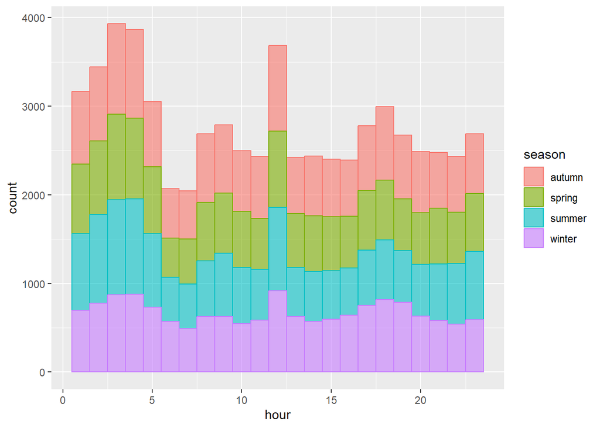

```r
toronto_be %>% ggplot(aes(x=hour, color=season,fill=season)) +
  geom_histogram(alpha=0.6, binwidth=1)
```

# Relationship between neighborhood and season

```r
con <- table(toronto_be$hood, toronto_be$season)
matrix <- apply(as.matrix.noquote(con),2,as.numeric)
column_margins <- colSums(con)
head(prop.table(con, margin = 2) * 100, 10)
```

```
##
##                                   autumn    spring    summer    winter
##   Agincourt North              0.6925946 0.6296248 0.5398697 0.7126198
##   Agincourt South-Malvern West 0.9885751 0.9152278 1.0176854 1.2568023
##   Alderwood                    0.3019002 0.3310399 0.2233944 0.4729204
##   Annex                        2.0422660 2.5379722 2.2401489 2.0601192
##   Avondale                     0.1775884 0.1233286 0.2233944 0.1166105
##   Banbury-Don Mills            0.9826555 0.9476827 0.8004964 1.1272350
##   Bathurst Manor               0.4439709 0.3440218 0.4095563 0.5960093
##   Bay-Cloverhill               0.7754691 0.6685707 0.7074155 1.0235812
##   Bayview Village              0.7162730 0.5127872 0.4157617 0.6284011
##   Bayview Woods-Steeles        0.4321317 0.2661301 0.3412969 0.4793988
```

```r
chi <- chisq.test(con)
chi
```

```
##
##  Pearson's Chi-squared test
##
## data:  con
## X-squared = 994.51, df = 474, p-value < 2.2e-16
```

Since there is significant differences in conditional probabilities between each column for each row, it is suggested that the two variables are not independent. We can perform a chi-square test to further investigate their independency. Based on p-value from the chi-square test, we can reject the null hypothesis that neighborhood is independent from season. This strongly indicates that there is an association between season and neighborhood.

#When and where do most break and enters occur?

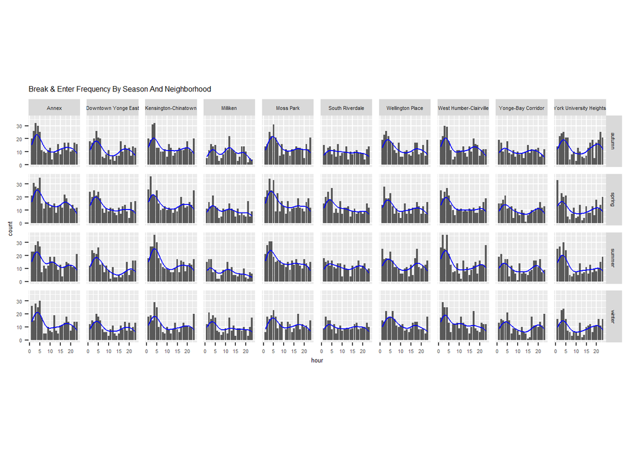

```r
temp_df <- as.data.frame(table(toronto_be$hood))
top10_hoods <- temp_df[rank(-temp_df$Freq)<=10,]$Var1
top_torontoBe <- subset(toronto_be, hood %in% top10_hoods)
top_torontoBe <- droplevels(top_torontoBe)
ggplot(data=top_torontoBe, aes(x=hour, y=after_stat(count))) +
  geom_bar() +
  geom_density(color="blue") +
  facet_grid(season~hood) +
  theme(aspect.ratio=10/10, text=element_text(size=5)) +
  labs(title="Break & Enter Frequency By Season And Neighborhood")
```

```r
library(leaflet)
reduced_torontoBe <- sample_n(toronto_be, 100)
map <- leaflet(reduced_torontoBe) %>%
  addTiles() %>%
  addMarkers(~lon, ~lat)
map
```

[interactive chart not shown]

Mapped randomly selected 100 observations from the population. Break & Enter becomes more frequent as we get closer to to downtown.

```r
library(leaflet)
hood_counts <- toronto_be %>%
  group_by(hood) %>%
  tally() %>%
  arrange(desc(hood))
lonlat <- toronto_be %>%
  group_by(hood) %>%
  summarise(
    lat = mean(lat),
    lon = mean(lon)
  ) %>%
  arrange(desc(hood))
hood_counts$lat <- lonlat$lat
hood_counts$lon <- lonlat$lon
leaflet(hood_counts) %>%
  addTiles() %>%
  addLabelOnlyMarkers(lng =~lon, lat=~lat, label =paste(hood_counts$hood, "count: " ,as.character(hood_counts$n)), labelOptions = labelOptions(noHide = TRUE))
```

[interactive chart not shown]